# Basics of MCMC sampling in Bayesian analysis

Last updated: 2019-10-23

## MCMC sampling

## Why sample?

- \(p(\theta \mid y)\) is a *distribution* but the shape of that distribution is not always directly attainable.
- For a normal prior on the mean and a normal likelihood function the posterior distribution for the mean is also a normal distribution.
- The normal is a *conjugate prior* for the normal likelihood. (The Beta distribution is conjugate for the binomial distribution).
- For most models an analytic expression of the posterior distribution is not possible.
- In these situations sampling is needed to approximate the posterior distribution. This is what is offered by software like JAGS, BUGS, Stan etc.

## Intro to MCMC

Markov Chain Monte Carlo

- *Markov Chain* - a "memoryless" chain of events. Each step depends on the current state (e.g. parameter value) and not previous ones
- *Monte Carlo* - Repeated random sampling

Goal of MCMC - to approximate a target distribution

## The Metropolis Algorithm

- We want to approximate \(p(\theta \mid y)\) which is proportional to the prior times the likelihood.
- The Metropolis algorithm allows us to explore the space of possible parameter values. Values are "visited" in proportion to their density under the posterior.

## The Metropolis Algorithm

1. Select a stating point in the parameter space. This is \(\theta_{\text{current}}\)
2. A move in parameter space is suggested from a *proposal distribution*. This is \(\theta_{\text{new}} = \theta_{\text{current}} + \Delta\theta\)
3. The probability that we accept the proposed move is: \(p_{\text{accept}} = \min\left(\frac{f(\theta_{\text{new}})}{f(\theta_{\text{current}})}, 1\right)\)
4. Sample a uniform number between 0 and 1. If this number is smaller than \(p_{\text{accept}}\) then we accept the proposal and \(\theta_{\text{new}}\) becomes \(\theta_{\text{current}}\) for the next step. If not we stick with the \(\theta_{\text{current}}\) we had originally.
5. Repeat steps 2-4 many times and record \(\theta_{\text{current}}\) at the beginning of each loop.

Note for our Bayesian purposes \(f(x) = p(x)p(y \mid x)\).

## The Metropolis Algorithm

Why does it work?

- If the proposed parameter value is "better" then the current value (i.e. produces a higher posterior density) then it is *always* visited.
- If it is not better than the current value it is visited in proportion to how it compares to the current value: \(f(\theta_{\text{new}})/f(\theta_{\text{current}})\)
- Thus, values with a higher posterior density are visited more often. Running a long chain and assessing how often certain parameter values are represented gives us the posterior even if we don't know how to express its form analytically.

## Metropolis Example

- Suppose we want to estimate the mean (\(\mu\)) IQ (or some other cognitive) score of a group of participants (N = 50).
- The test is scaled to have a population standard deviation of 15 so we assume that this is known.

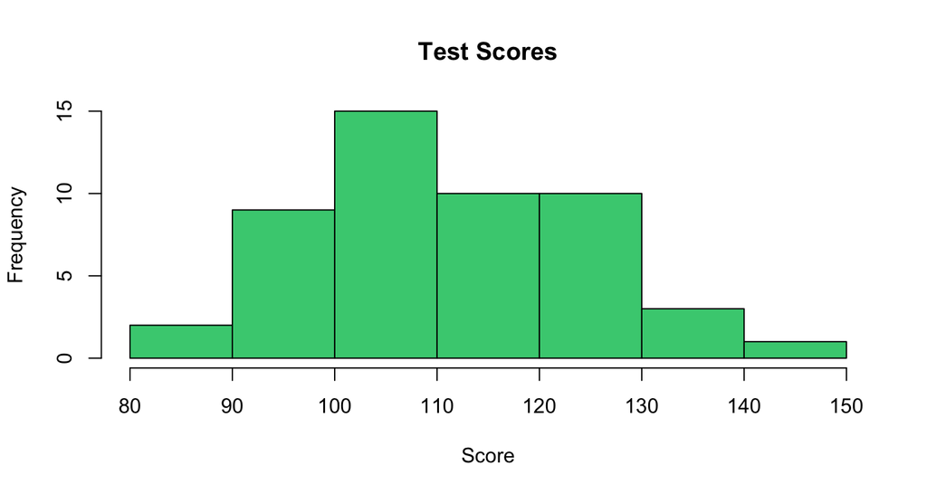

## Metropolis Example

- We need to choose a prior distribution for \(\mu\)
- Here we use a normal distribution with a mean of 100 and standard deviation of 10

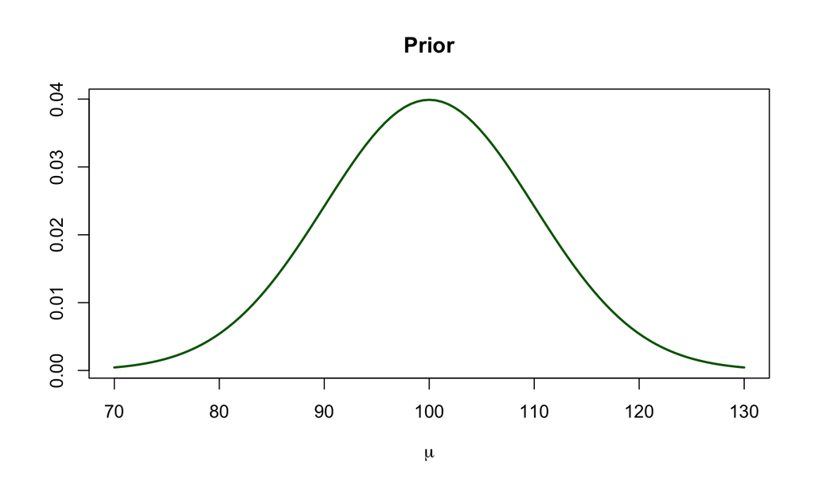

## Metropolis Example

- The script `metropolis-example.R` contains code implementing a Metropolis algorithm
- Have a look to see what is involved…

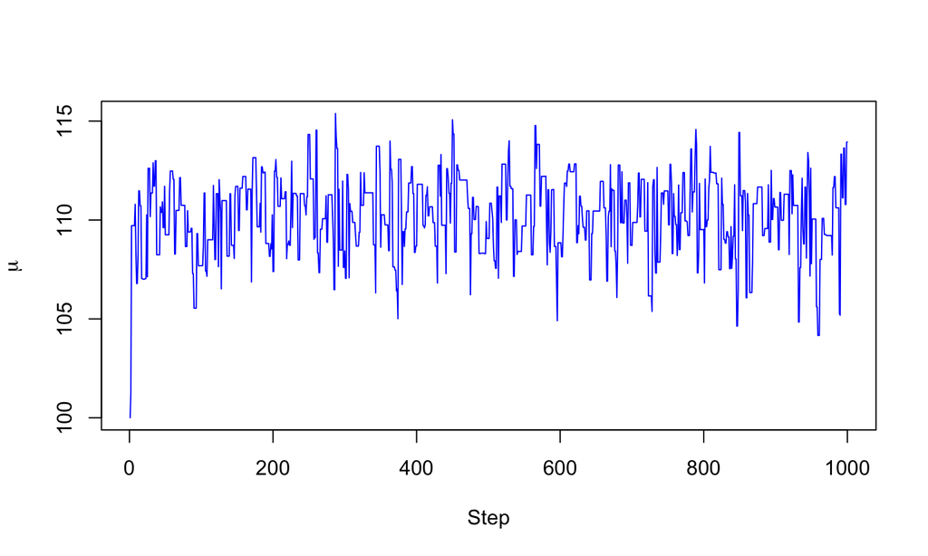

## Let's take a look at some steps

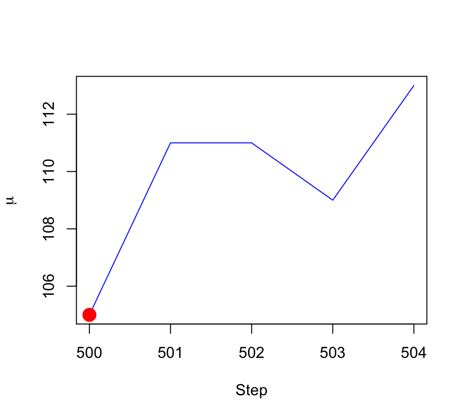

**Step 500**

- The current value of \(\mu\) is 105. A new value is proposed from a normal distribution with a mean of 105 and a standard deviation of 5. The proposed value is 111.
- Next we calculate \(p(\mu)p(y \mid \mu)\) for both the current and proposed values of \(\mu\) (we use the `dnorm` function twice as both the prior and the likelihood are normal).
- In this case \(p_{\text{accept}} = 1\) so we accept the proposal for step 501

## Let's take a look at some steps

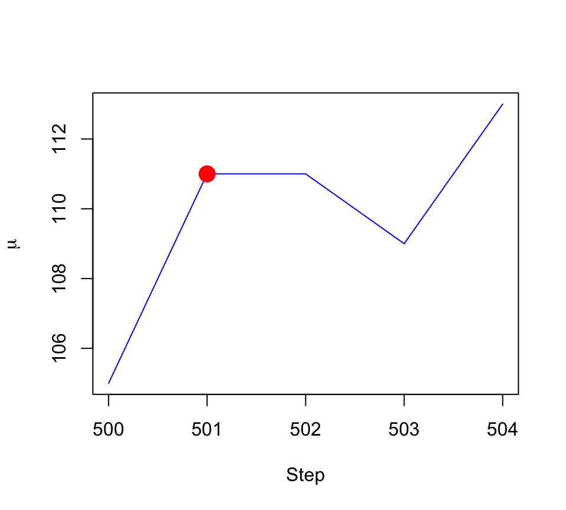

**Step 501**

## Let's take a look at some steps

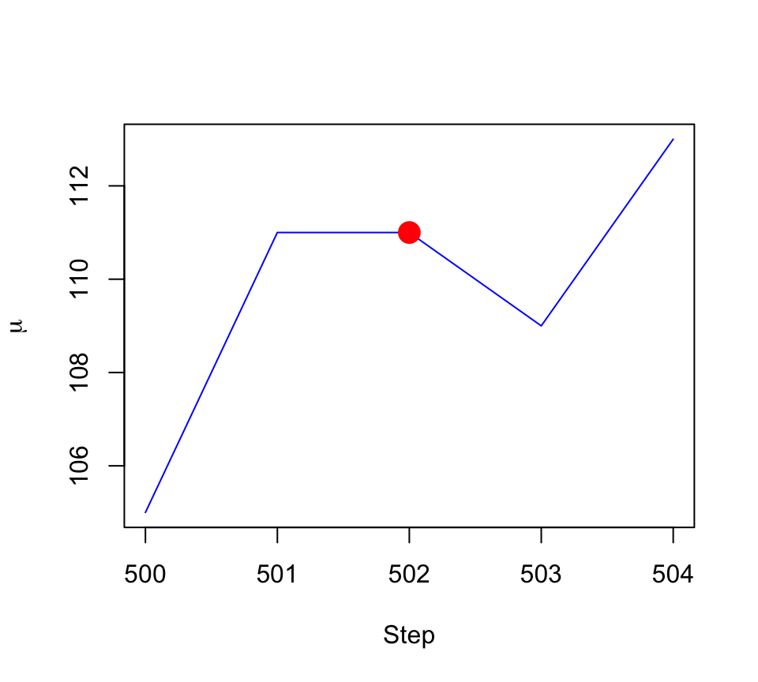

**Step 502**

- The current value of \(\mu\) is 111. The proposed value is 109.
- The ratio of \(p(\mu)p(y \mid \mu)\) for proposed relative to current value of \(\mu\) gives \(p_{\text{accept}} = .8\)
- The number sampled via `runif(n = 1, min = 0, max = 1)` is 0.34 so the proposal is *accepted*
- The current value is set to 109 for step 503.

and so on…

## It works!

For a normal likelihood with a normal prior on the mean the form of the posterior distribution is known. So we can compare the results.

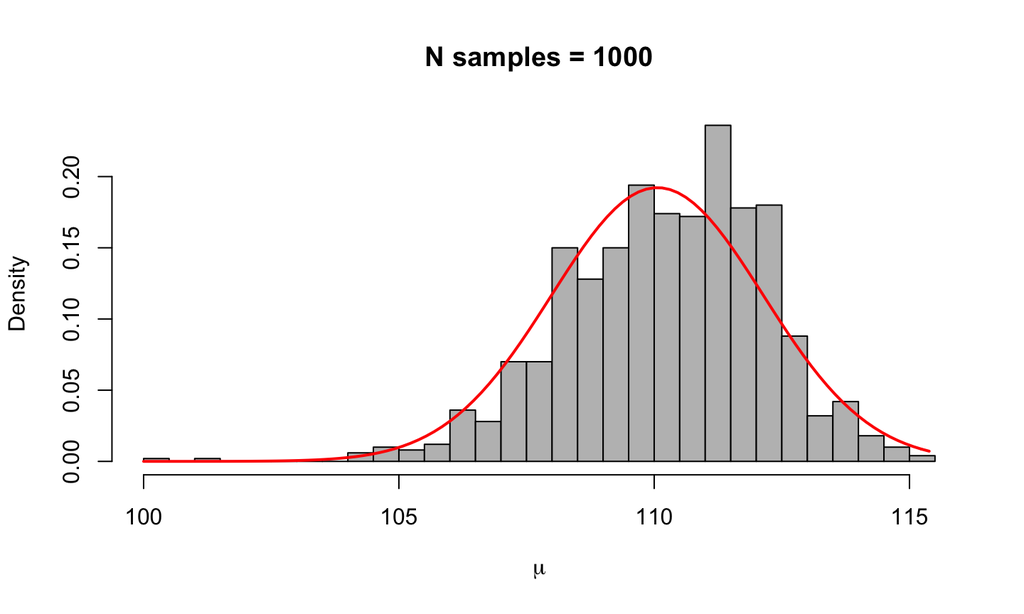

## It works!

Increasing the number of steps improves the approximation.

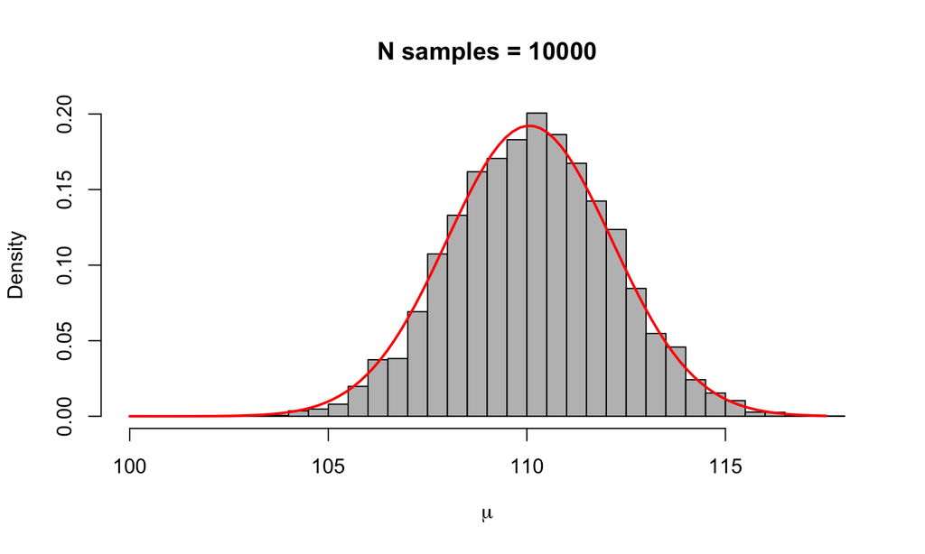

## Gibbs Sampling

## Gibbs Sampling

More complicated than our Metropolis algorithm but better for large numbers of parameters, which easily occurs in hierarchical modeling. Imagine a two parameter situation \(\{\theta_1, \theta_2\}\) with independent prior distributions \(p(\theta_1, \theta_2) = p(\theta_1)p(\theta_2)\).

1. Start at a random point in the (two dimensional) parameter space.
2. Select one of the parameters (e.g. \(\theta_1\)). Sample a new value for it from \(p(\theta_1 \mid \theta_2, y)\) using the current value of the other parameters (in this case, \(\theta_2\)).
3. The sampled value comes directly from the posterior of \(\theta_1\) conditional on the current value of \(\theta_2\) so the move is *always* accepted.
4. Go back to step 2 and repeat many times.

## Sampling in Stan

- Stan uses an even more complex algorithm, called [Hamiltonian Monte Carlo](https://en.wikipedia.org/wiki/Hamiltonian_Monte_Carlo) (specifically, a No-U Turn Sampler, NUTS)
- This is more effective for high dimensional problems
- The main difference is in how proposals for the next step are generated
- See [Betancourt (2017)](https://arxiv.org/pdf/1701.02434.pdf) for a conceptual introduction